# Board_games

Yifei Liu

3/15/2019

```r
library(tidyverse)
detach("package:dplyr", unload=TRUE)
library(dplyr)
library(broom)
library(glmnet)
library(tidytext)
library(Matrix)
theme_set(theme_minimal())
library(scales)
```

```r
board_games_raw <- read_csv("https://raw.githubusercontent.com/rfordatascience/tidytuesday/master/data/2019/2019-03-12/board_games.csv")
holdout_set <- board_games_raw %>%
  filter(game_id %% 5 == 0)

board_games <- board_games_raw %>%
  filter(game_id %% 5 != 0)
```

### EDA

```r
board_games %>%
  count(publisher, sort = T)
```

```
## # A tibble: 4,564 x 2
##    publisher                                n
##    <chr>                                <int>
##  1 GMT Games                              149
##  2 SPI (Simulations Publications, Inc.)    99
##  3 Avalon Hill                             83
##  4 Ravensburger Spieleverlag GmbH          81
##  5 Decision Games (I)                      55
##  6 KOSMOS                                  55
##  7 Queen Games                             55
##  8 Avalanche Press Ltd.                    50
##  9 (Self-Published)                        48
## 10 Games Workshop Ltd.                     48
## # … with 4,554 more rows
```

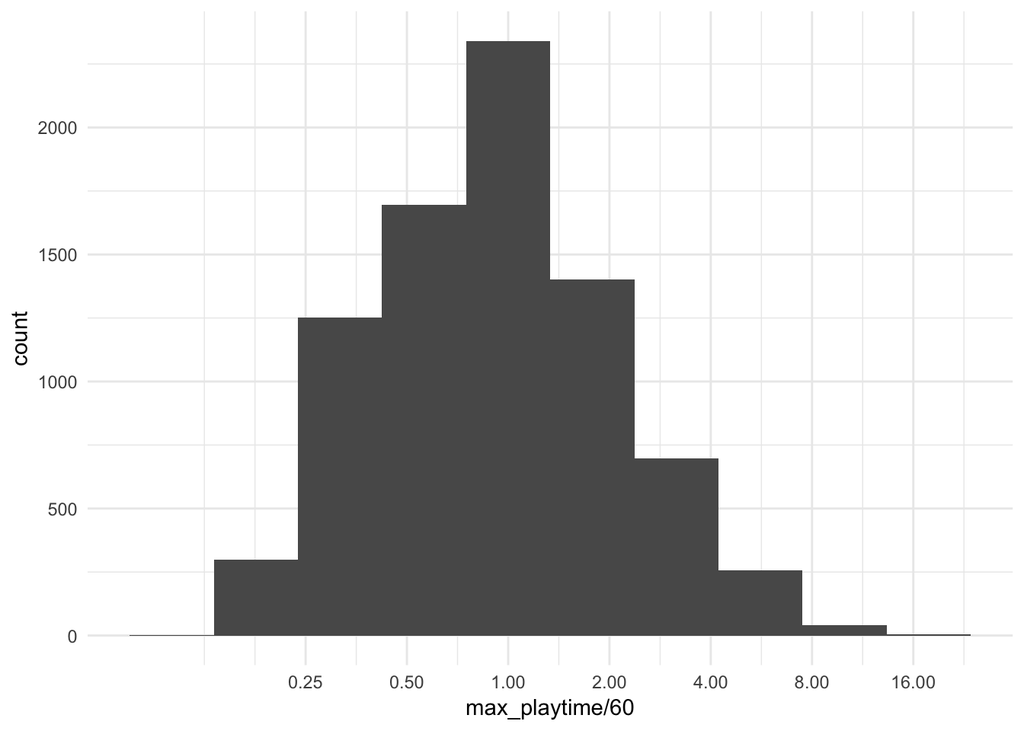

```r
board_games %>%
  filter(max_playtime > 5, max_playtime < 1000) %>%
  ggplot(aes(max_playtime / 60)) +
  geom_histogram(binwidth = 0.25) +
  scale_x_log10(breaks = 2 ^ seq(-2, 4))
```

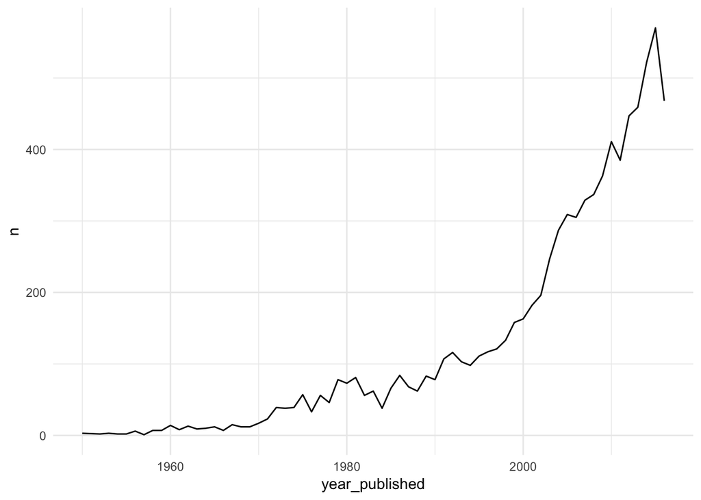

```r
board_games %>%
  count(year_published , sort = T) %>%
  ggplot(aes(year_published, n)) +
  geom_line()
```

Categorical variables:

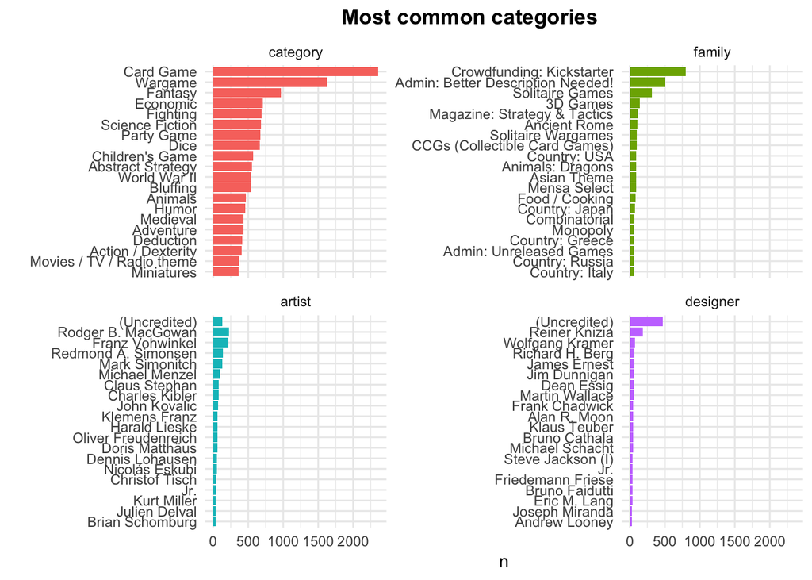

```r
categorical_variables <- board_games %>%
  select(game_id, name, family, category, artist, designer) %>%
  gather(type, value, -game_id, -name) %>%
  filter(!is.na(value)) %>%
  separate_rows(value, sep = ",") %>%
  arrange(game_id)

categorical_counts <- categorical_variables %>%
  count(type, value, sort = T)


categorical_counts %>%
  group_by(type) %>%
  top_n(20, n) %>%
  ungroup() %>%
  mutate(value = fct_reorder(value, n),
         type = fct_reorder(type, n, .desc = T)) %>%
  ggplot(aes(value, n, fill = type)) +
  geom_col(show.legend = F) +
  coord_flip() +
  facet_wrap( ~ type, scales = "free_y") +
  labs(title = "Most common categories", x = "") +
  theme(plot.title = element_text(hjust = 0.4, face = "bold"))
```

### Predict average rating

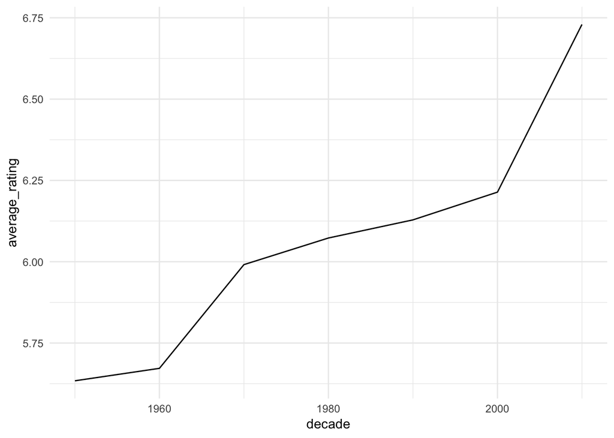

```r
board_games %>%
  mutate(decade = 10 * (year_published %/% 10)) %>%
  group_by(decade) %>%
  summarize(average_rating = mean(average_rating)) %>%
  ggplot(aes(decade, average_rating)) +
  geom_line()
```

Applied lm model on this dataset, since we already have numeric variable and categorical variables

we need to split the dataset into training and testing dataset.

```r
lm(average_rating ~
     log2(max_players + 1) +
     log2(max_playtime + 1) +
     year_published, board_games) %>%
  tidy()
```

```
## # A tibble: 4 x 5
##   term                   estimate std.error statistic   p.value
##   <chr>                     <dbl>     <dbl>     <dbl>     <dbl>
## 1 (Intercept)            -47.3     1.35         -34.9 2.09e-249
## 2 log2(max_players + 1)   -0.190   0.0116       -16.4 1.18e- 59
## 3 log2(max_playtime + 1)   0.165   0.00507       32.5 3.10e-218
## 4 year_published           0.0266  0.000675      39.4 3.45e-311
```

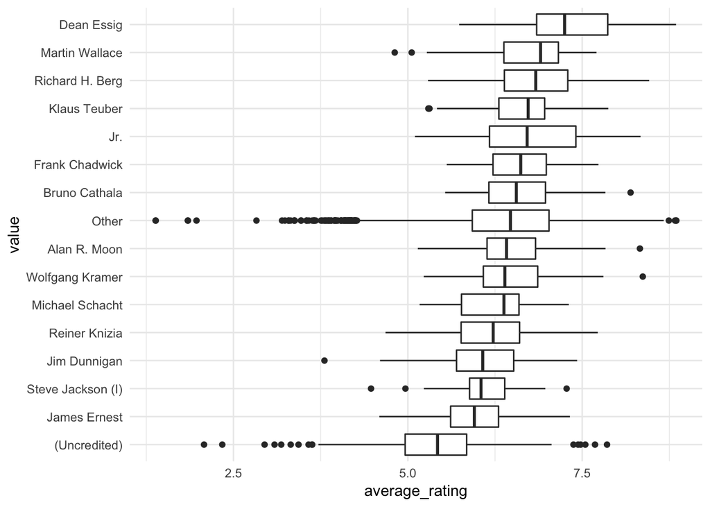

```r
by_categorical <- board_games %>%
  inner_join(categorical_variables, by = c("game_id", "name")) %>%
  select(type, value, average_rating) %>%
  group_by(type, value) %>%
  summarize(games = n(),
            average_rating = mean(average_rating)) %>%
  arrange(desc(games))


board_games %>%
  inner_join(categorical_variables, by = c("game_id", "name")) %>%
  filter(type ==  "designer") %>%
  mutate(value = fct_lump(value, 15),
         value = fct_reorder(value, average_rating)) %>%
  ggplot(aes(value, average_rating)) +
  geom_boxplot() +
  coord_flip()
```

Conclusion: Categorical variables can be correlated with higher/lower rated games

```r
non_categorical_features <- board_games %>%
  transmute(game_id,
            name,
            year = year_published - 1950,
            log2_max_players = log2(max_players + 1),
            log2_max_playtime = log2(max_playtime + 1)) %>%
  gather(feature, value, - game_id, -name)


features <- categorical_variables %>%
  unite(feature, type, value, sep = ": ") %>%
  add_count(feature) %>%
  filter(n >= 20) %>%
  mutate(value = 1) %>%
  bind_rows(non_categorical_features)

# x

features_matrix <- features %>%
  cast_sparse(game_id, feature, value)

# y

ratings <- board_games$average_rating[match(rownames(features_matrix), board_games$game_id)]

cv_lasso <- cv.glmnet(features_matrix, ratings)


cv_lasso$lambda.1se
```

```
## [1] 0.01032519
```

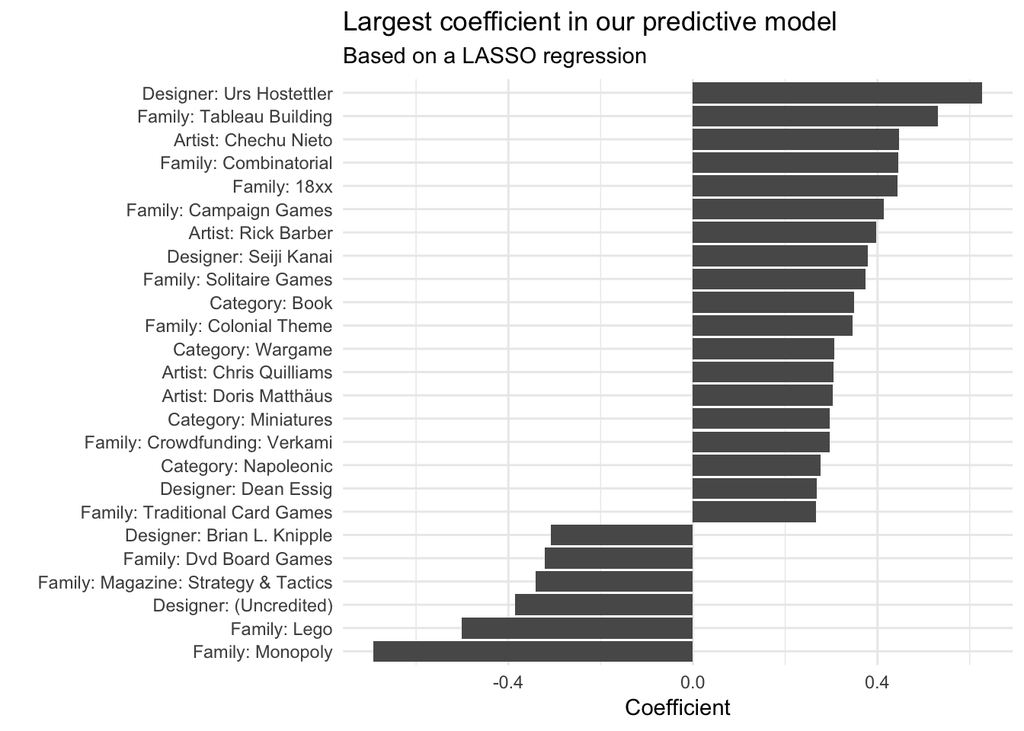

```r
cv_lasso$glmnet.fit %>%
  tidy() %>%
  filter(lambda == cv_lasso$lambda.1se) %>%
  arrange(desc(estimate)) %>%
  filter(term != "(Intercept)") %>%
  top_n(25, abs(estimate)) %>%
  mutate(term = str_to_title(term),
         term = fct_reorder(term, estimate)) %>%
  ggplot(aes(term, estimate)) +
  geom_col() +
  coord_flip() +
  labs(title = "Largest coefficient in our predictive model",
       subtitle = "Based on a LASSO regression",
       x = "",
       y = "Coefficient")
```

### Further Analysis: DIY

Due to time limit, there’re some futher analysis lift on the table

1. Use yardstick package and compare lasso model to other model. Since lasso is a linear model, every term just been added in, it doesn’t allow non linear relationship and it doesn’t allow for interaction, such as you are both a compaign game and you have this designer.
2. Lasso regression is very intuitive. Such as even though you don’t really understand how you choose the value of lambda, but you do understand the coefficient.
3. In this analysis, we do some EDA and ML, beside compare model, you can do to look at the word used in the describtion that would give more information about average_rating.